# ps03_progresa_HsinyuTso

## Introduction

For this assignment, you will be using data from the [Progresa program](http://en.wikipedia.org/wiki/Oportunidades), a government social assistance program in Mexico. This program, as well as the details of its impact, are described in the paper "[School subsidies for the poor: evaluating the Mexican Progresa poverty program](http://www.sciencedirect.com/science/article/pii/S0304387803001858)", by Paul Shultz (available on Canvas). The data (progresa_sample.csv.gz) is available on canvas in files/data.

Please read the paper to familiarize yourself with the PROGRESA program before beginning this problem set, so you have a rough sense of where the data come from and how they were generated. If you just proceed into the problem set without understanding Progresa or the data, it will be very difficult!

The goal of this problem set is to implement some of the basic econometric techniques that you are learning in class to measure the impact of Progresa on secondary school enrollment rates, in particular differences-in-differences. Your task is to **estimate the impact of *progresa* subsidies on the school attendance**. Note: this asks to estimate a causal effect.

The timeline of the program was:

- Baseline survey conducted in 1997
- Intervention begins in 1998, "Wave 1" of data collected in 1998
- "Wave 2 of data" collected in 1999
- Evaluation ends in 2000, at which point the control villages were treated.

When you are ready, download the progresa_sample.csv data from Canvas. The data are actual data collected to evaluate the impact of the Progresa program. In this file, each row corresponds to an observation taken for a given child for a given year. There are two years of data (1997 and 1998), and just under 40,000 children who are surveyed in both years. For each child-year observation, the following variables are collected:

| Variable name | Description |
| --- | --- |
| year | year in which data is collected |
| sex | male = 1 |
| indig | indigenous = 1 |
| dist_sec | nearest distance to a secondary school |
| sc | enrolled in school in year of survey (=1) |
| grc | grade enrolled |
| fam_n | family size |
| min_dist | min distance to an urban center |
| dist_cap | min distance to the capital |
| poor | poor = "pobre", not poor = "no pobre" |
| progresa | treatment = "basal", control = "0" |
| hohedu | years of schooling of head of household |
| hohwag | monthly wages of head of household |
| welfare_index | welfare index used to classify poor |
| hohsex | gender of head of household (male=1) |
| hohage | age of head of household |
| age | years old |
| folnum | individual id |
| village | village id |
| sc97 | enrolled in school in 1997 (=1) |

## Part 1: Descriptive analysis

### 1.1 Summary Statistics

Report summary statistics (mean, standard deviation, and number of missings) for all of the demographic variables in the dataset (i.e., everything except year, folnum, village). A central variable, *progresa* is coded in a rather unintuitive way. Find it's actual coding scheme (levels). Does this fit with the documentation above?

Present these in a single table alphabetized by variable name. Do NOT simply expect the grader to scroll through your output!

```python
import pandas as pd
import numpy as np
from scipy import stats
import matplotlib.pyplot as plt
import matplotlib
%matplotlib inline
```

```python
# Summary of mean and standard deviation
progresa_df = pd.read_csv("progresa_sample.csv.gz")
progresa_summary = progresa_df.describe()
print("Summary of mean and standard deviation:")
progresa_summary.loc[['mean','std']][['sex','indig','dist_sec','sc','grc','fam_n','min_dist','dist_cap',
                                     'hohedu','hohwag','welfare_index','hohsex','hohage','age','grc97','sc97']]
```

```
Summary of mean and standard deviation:
```

|  | sex | indig | dist_sec | sc | grc | fam_n | min_dist | dist_cap | hohedu | hohwag | welfare_index | hohsex | hohage | age | grc97 | sc97 |
| --- | --- | --- | --- | --- | --- | --- | --- | --- | --- | --- | --- | --- | --- | --- | --- | --- |
| mean | 0.512211 | 0.298324 | 2.418910 | 0.819818 | 3.963537 | 7.215715 | 103.447520 | 147.674452 | 2.768104 | 586.985312 | 690.346564 | 0.925185 | 44.436717 | 11.366460 | 3.705372 | 0.813922 |
| std | 0.499854 | 0.457525 | 2.234109 | 0.384342 | 2.499063 | 2.352900 | 42.089441 | 76.063134 | 2.656106 | 788.133664 | 139.491130 | 0.263095 | 11.620372 | 3.167744 | 2.572387 | 0.389172 |

```python
# Missing data counts
missing = progresa_df.isnull().sum(axis=0)
print("Missing data counts:")
missing[['sex','indig','dist_sec','sc','grc','fam_n','min_dist','dist_cap','poor','progresa',
                                     'hohedu','hohwag','welfare_index','hohsex','hohage','age','grc97','sc97']]
```

```
Missing data counts:
```

```
sex                24
indig             300
dist_sec            0
sc               8453
grc              6549
fam_n               0
min_dist            0
dist_cap            0
poor                0
progresa            0
hohedu              0
hohwag              0
welfare_index     210
hohsex             20
hohage             10
age                 0
grc97               0
sc97             3872
dtype: int64
```

```python
# Find progresa's actual coding scheme
progresa_df.progresa.unique()
```

```
array(['0', 'basal'], dtype=object)
```

The actual coding is '0', 'basal', which is same as the document above (treatment = "basal", control = "0"). It is unusual becase it include string to name the coding. It would be better to replace "basal" with number like 1.

### 1.2 Differences at baseline?

Now let's investigate the differences in baseline. Are the baseline (1997) demographic characteristics **for the poor** different in treatment and control villages?

I suggest you to use a T-Test to determine whether there is a statistically significant difference in the average values of each of the variables in the dataset. Focus only on the data from 1997 for poor.

Present your results in a single table with the following columns and 14 (or so) rows:

| Variable name | Average value (Treatment villages) | Average value (Control villages) | Difference (Treat - Control) | p-value |
| --- | --- | --- | --- | --- |
| Male | ? | ? | ? | ? |

```python
# extract data for year=97 and poor
df= progresa_df[(progresa_df['year']==97) & (progresa_df['poor'] =='pobre')]

# drop unnecessary columns and NaN
df= df.drop(['year', 'folnum', 'village','poor'], axis=1)
df = df.dropna()

# seperate control and treatment (by progresa)
treat = df[df['progresa']=='basal'].drop(['progresa'], axis=1)
control =df[df['progresa']=='0'].drop(['progresa'], axis=1)
```

```python
# create table
base = pd.DataFrame({ 'Average value (Treatment villages)': treat.describe().loc['mean'].transpose(),
                      'Average value (Control villages)': control.describe().loc['mean'].transpose() })
```

```python
# add "difference" column and calculate difference (Treat - Control)
base['Difference (Treat - Control)'] = base['Average value (Treatment villages)']- base[ 'Average value (Control villages)']
```

```python
# stats.ttest_ind: calculate the T-test for the means of two independent samples of scores
# create a p value column, run t test than calculate p value
base['p-value']= stats.ttest_ind(treat, control, equal_var=False).pvalue.round(4)
```

```python
base
```

|  | Average value (Treatment villages) | Average value (Control villages) | Difference (Treat - Control) | p-value |
| --- | --- | --- | --- | --- |
| sex | 0.520268 | 0.506556 | 0.013713 | 0.0196 |
| indig | 0.316744 | 0.325306 | -0.008562 | 0.1190 |
| dist_sec | 2.399648 | 2.400687 | -0.001039 | 0.9681 |
| sc | 0.822697 | 0.815066 | 0.007631 | 0.0925 |
| grc | 3.709214 | 3.733653 | -0.024439 | 0.3955 |
| fam_n | 7.281032 | 7.302939 | -0.021907 | 0.4261 |
| min_dist | 107.395231 | 103.098348 | 4.296884 | 0.0000 |
| dist_cap | 151.801472 | 154.492095 | -2.690622 | 0.0044 |
| hohedu | 2.726729 | 2.660982 | 0.065747 | 0.0250 |
| hohwag | 550.207086 | 580.694452 | -30.487366 | 0.0003 |
| welfare_index | 656.810476 | 661.593513 | -4.783037 | 0.0004 |
| hohsex | 0.925586 | 0.923387 | 0.002199 | 0.4795 |
| hohage | 43.631234 | 44.270717 | -0.639483 | 0.0000 |
| age | 10.743825 | 10.785586 | -0.041761 | 0.2474 |
| grc97 | 3.709214 | 3.733653 | -0.024439 | 0.3955 |
| sc97 | 0.822697 | 0.815066 | 0.007631 | 0.0925 |

### 1.3 Interpretation

- A: Are there statistically significant differences between treatment and control villages as baseline?
- B: Why does it matter if there are differences at baseline?
- C: What does this imply about how to measure the impact of the treatment?

### A:

As we can see in the p-values columns, some of the values are less than 0.05, for example hohwag, meaning the differences are statistically significant. On the other hand, some of the p-values, like sc, are larger than 0.05 which mean that the differences between treatment and control valiages as baseline are not statistically significant.

### B:

It is important to ensure the control group and treatment group are randomly selected and there're no significant differences between them. Checking if there are differences at baseline helps the following study of causal relationships between parameters.

### C:

By having randomly assigned research target into control and treatment groups, we can measure the impact of treatment through comparing two groups and studying the differences of control and treatment groups. Since we found some of the differences between variables are statistically significant, we should consider the impact of these variables while doing further research steps.

### 1.4 Graphical exploration, part 1

For each level of household head education, compute the average enrollment rate in 1997. Create a scatterplot that shows this relationship. What do you notice?

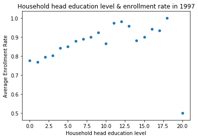

```python
# group the data by hohedu in year 1997
enrol = pd.DataFrame(progresa_df[progresa_df['year']==97].groupby('hohedu').mean()['sc'])
enrol.reset_index(level = 0, inplace = True)

# plot the data
ax = enrol.plot.scatter(x='hohedu', y='sc', title='Household head education level & enrollment rate in 1997')
ax.set_xlabel('Household head education level')
ax.set_ylabel('Average Enrollment Rate')
```

The average school enrollment rates rise as the household head education level is higher. The average school enrollment rates increase stably from 0.77 to around 1.0. In addition, there are some interesting findings in this graph, for example, the school enrollment rate drop at the 10 year, and it also finally drops to 0.5 as the household head education is 20 year.

### 1.5 Graphical exploration, part 2

1. On each histogram, draw a vertical line that intersects the x-axis at the average value (across all households). Does there appear to be a difference? Is this difference statistically significant?

```python
# extract poor, treatment data from year 1997 and 1998
df97= progresa_df[(progresa_df['poor'] == 'pobre') & (progresa_df['year']==97) & (progresa_df['progresa']=='basal')]
df98= progresa_df[(progresa_df['poor'] == 'pobre') & (progresa_df['year']==98) & (progresa_df['progresa']=='basal')]
```

```python
# group by village and calculate the average enrollment rates
df97_group = df97.groupby('village').mean()['sc']
df98_group = df98.groupby('village').mean()['sc']
```

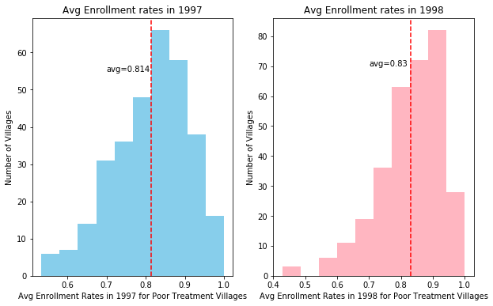

```python
fig = plt.figure(figsize=(10, 6))
ax1 = fig.add_subplot(121)
ax1.hist(df97_group,color = 'skyblue')
plt.xlabel('Avg Enrollment Rates in 1997 for Poor Treatment Villages')
plt.ylabel('Number of Villages')
plt.axvline(df97_group.mean(),color='red',linestyle='dashed')
plt.text(0.7, 55, 'avg='+ str(round(df97_group.mean(),3)))
plt.title('Avg Enrollment rates in 1997')

ax2 = fig.add_subplot(122)
ax2.hist(df98_group, color = 'lightpink')
plt.xlabel('Avg Enrollment Rates in 1998 for Poor Treatment Villages')
plt.ylabel('Number of Villages')
plt.axvline(df98_group.mean(),color='red',linestyle='dashed')
plt.text(0.7, 70, 'avg='+ str(round(df98_group.mean(),3)))
plt.title('Avg Enrollment rates in 1998')
```

```python
#t-test on enrollment rate in 1997 and 1998, and calculate the p value
p = stats.ttest_ind(df97_group, df98_group, equal_var=False).pvalue
print('P-value : ', p)
```

```
P-value :  0.044249343422588405
```

The histograms show that the mean of the average enrollment rates across villages in 1997 and 1998 has mostly remained the same around 0.814 and 0.83. The histograms also illustrate a change in more villages going higher to the 0.8 and 0.9 range in 1998 as compared to the treatment villages in 1997. Although the p-value(0.044) is less than 0.05 and thus being statistically significant, it is not significant in a large extent.

## Part 2: Measuring Impact

Our goal is to estimate the causal impact of the PROGRESA program on the social and economic outcomes of individuals in Mexico. We will focus on the impact of the program on the poor (those with poor=='pobre'), since only the poor were eligible to receive the PROGRESA assistance.

### 2.1 Cross-Sectional Estimator: T-test

Begin by estimating the impact of Progresa using "simple differences." Restricting yourself to data from 1998 (after treatment), calculate the average enrollment rate among **poor** households in the Treatment villages and the average enrollment rate among **poor** households in the control villages. Use a t-test to determine if this difference is statistically significant. What do you conclude?

```python
# data from 1998 in poor villages
treatment = progresa_df[(progresa_df['year']==98) & (progresa_df['poor']=='pobre') & (progresa_df['progresa'] == 'basal')]
control = progresa_df[(progresa_df['year']==98) & (progresa_df['poor']=='pobre') & (progresa_df['progresa'] == '0')]
```

```python
# Avg. enrollment for treatment and control villages
treat_enroll = treatment['sc'].mean()
control_enroll = control['sc'].mean()
print('Avg. Enrollment for Treatment Villages in 1998:',treat_enroll)
print('Avg. Enrollment for Control Villages in 1998:',control_enroll)
```

```
Avg. Enrollment for Treatment Villages in 1998: 0.8464791213954308
Avg. Enrollment for Control Villages in 1998: 0.807636956730308
```

```python
#t-test and p-value
stats.ttest_ind(treatment['sc'].dropna(),control['sc'].dropna(), equal_var=False)
```

```
Ttest_indResult(statistic=8.181477157107308, pvalue=2.9655072988948406e-16)
```

The average enrollment rate for treatment and control village are 0.8464 and 0.8076. By calculating the t-test and the p-value, we can find the p-value less than 0.05 and really close to 0, meaning the difference between treatment and control villages is statistically significant. Based on the result, we can conclude that the progresa helped increase the enrollment rate among poor households.

### 2.2 Cross-Sectional Estimator: Regression

Estimate the effects of Progresa on enrollment using a regression model, by regressing the 1998 enrollment rates **of the poor** on treatment assignment. Do not include any additional control variables. Discuss the following:

- Based on this model, how much did Progresa increase the likelihood of a child enrolling?
- How does your regression estimate compare to your t-test estimate from part 2.1?
- Based on this regression model, can we reject the null hypothesis that the treatment effects are zero?
- What is the counterfactual assumption underlying this regression?

Note: I recommend to use statsmodels.formula.api as this allows to use convenient R-style formulas and provedes nice summaries of the results.

```python
import statsmodels.api as sm
import statsmodels.formula.api as smf
```

```python
# filter data
df = progresa_df[(progresa_df['year']==98) & (progresa_df['poor']=='pobre')].dropna()

# linear regression model
mod = smf.ols(formula='sc ~ progresa', data = df)
result = mod.fit()
result.summary()
```

OLS Regression Results

| Dep. Variable: | sc | R-squared: | 0.003 |
| --- | --- | --- | --- |
| Model: | OLS | Adj. R-squared: | 0.002 |
| Method: | Least Squares | F-statistic: | 65.64 |
| Date: | Fri, 15 Feb 2019 | Prob (F-statistic): | 5.66e-16 |
| Time: | 23:45:30 | Log-Likelihood: | -11171. |
| No. Observations: | 26155 | AIC: | 2.235e+04 |
| Df Residuals: | 26153 | BIC: | 2.236e+04 |
| Df Model: | 1 |  |  |
| Covariance Type: | nonrobust |  |  |

|  | coef | std err | t | P>\|t\| | [0.025 | 0.975] |
| --- | --- | --- | --- | --- | --- | --- |
| Intercept | 0.8109 | 0.004 | 217.190 | 0.000 | 0.804 | 0.818 |
| progresa[T.basal] | 0.0383 | 0.005 | 8.102 | 0.000 | 0.029 | 0.048 |

| Omnibus: | 7487.800 | Durbin-Watson: | 1.734 |
| --- | --- | --- | --- |
| Prob(Omnibus): | 0.000 | Jarque-Bera (JB): | 15756.374 |
| Skew: | -1.796 | Prob(JB): | 0.00 |
| Kurtosis: | 4.245 | Cond. No. | 3.02 |

Warnings:  
[1] Standard Errors assume that the covariance matrix of the errors is correctly specified.

### 2.3 Multiple Regression

Re-run the above regression estimated but this time include a set of relevant control variables. Include, for instance, age, distance to a secondary school, gender, education of household head, welfare index, indigenous, etc.

- How do the controls affect the point estimate of treatment effect?
- How do the controls affect the standard error on the treatment effect?
- How do you interpret the differences (or similarities) between your estimates of 2.2 and 2.3?

```python
# dummy variable
df['sex'] = df['sex'].astype('category')
df['indig'] = df['indig'].astype('category')
multiple_lm = smf.ols(formula='sc ~progresa+age+dist_sec+sex+hohedu+indig', data=df).fit()
multiple_lm.summary()
```

OLS Regression Results

| Dep. Variable: | sc | R-squared: | 0.263 |
| --- | --- | --- | --- |
| Model: | OLS | Adj. R-squared: | 0.263 |
| Method: | Least Squares | F-statistic: | 1557. |
| Date: | Fri, 15 Feb 2019 | Prob (F-statistic): | 0.00 |
| Time: | 23:45:33 | Log-Likelihood: | -7208.4 |
| No. Observations: | 26155 | AIC: | 1.443e+04 |
| Df Residuals: | 26148 | BIC: | 1.449e+04 |
| Df Model: | 6 |  |  |
| Covariance Type: | nonrobust |  |  |

|  | coef | std err | t | P>\|t\| | [0.025 | 0.975] |
| --- | --- | --- | --- | --- | --- | --- |
| Intercept | 1.5206 | 0.010 | 157.308 | 0.000 | 1.502 | 1.539 |
| progresa[T.basal] | 0.0349 | 0.004 | 8.590 | 0.000 | 0.027 | 0.043 |
| sex[T.1.0] | 0.0308 | 0.004 | 7.809 | 0.000 | 0.023 | 0.039 |
| indig[T.1.0] | 0.0494 | 0.004 | 11.684 | 0.000 | 0.041 | 0.058 |
| age | -0.0650 | 0.001 | -92.563 | 0.000 | -0.066 | -0.064 |
| dist_sec | -0.0110 | 0.001 | -11.804 | 0.000 | -0.013 | -0.009 |
| hohedu | 0.0082 | 0.001 | 10.346 | 0.000 | 0.007 | 0.010 |

| Omnibus: | 3020.420 | Durbin-Watson: | 1.718 |
| --- | --- | --- | --- |
| Prob(Omnibus): | 0.000 | Jarque-Bera (JB): | 4179.881 |
| Skew: | -0.968 | Prob(JB): | 0.00 |
| Kurtosis: | 3.293 | Cond. No. | 61.1 |

Warnings:  
[1] Standard Errors assume that the covariance matrix of the errors is correctly specified.

- By adding control variables, the coeffcient of the estimate of treatment effect moves from 0.0383(in single-linear regression) to 0.0349.
- Having more control variables in the model reduce the standard error from 0.005 to 0.004. In this case, including more variables help the model to predict more accurate.
- Comparing the two results, point estimate and standard error both decrease, meaning the controls did affect the model. In this case, having controls help the model become more accurate. Both of the models show the positive value of treatment, meaning the treatment had truely improved the school enrollment.

### 2.4 Difference-in-Difference, version 1 (tabular)

Thus far, we have computed the effects of Progresa by estimating the difference in 1998 enrollment rates across villages. An alternative approach would be to compute the treatment effect using a difference-in-differences framework.

Begin by estimating the average treatment effects of the program for poor households using data from 1997 and 1998. Specifically, calculate:

a) the difference (between 1997 and 1998) in enrollment rates among poor households in treated villages

b) the difference (between 1997 and 1998) in enrollment rates among poor households in control villages.

c) The difference between these two differences is your estimate.

- What is your estimate of the impact, and how does it compare to your earlier (simple difference) results?
- What is the counterfactual assumption underlying this estimate?

```python
data97 = progresa_df[(progresa_df['poor'] == "pobre") & (progresa_df['year'] == 97)]
data98 = progresa_df[(progresa_df['poor'] == "pobre") & (progresa_df['year'] == 98)]

# Calculating mean values
treat98 = data98['sc'][data98.progresa == "basal"].mean()
treat97 = data97['sc'][data97.progresa == "basal"].mean()
control98 =  data98['sc'][data98.progresa == "0"].mean()
control97 =  data97['sc'][data97.progresa == '0'].mean()
```

```python
index = ['(a)Difference in enrollment rates among poor households(treated)', '(b)Difference in enrollment rates among poor households(control)','(c) Diff in dff: (a)-(b)']
cols = ['value']
dd = pd.DataFrame(index = index, columns = cols)
```

```python
dd.loc['(a)Difference in enrollment rates among poor households(treated)',"value"] = (treat98 - treat97)
dd.loc['(b)Difference in enrollment rates among poor households(control)',"value"] = (control98 - control97)
dd.loc['(c) Diff in dff: (a)-(b)',"value"] = (treat98 - treat97) - (control98 - control97)
```

```python
dd
```

|  | value |
| --- | --- |
| (a)Difference in enrollment rates among poor households(treated) | 0.0237822 |
| (b)Difference in enrollment rates among poor households(control) | -0.00754905 |
| (c) Diff in dff: (a)-(b) | 0.0313313 |

### 2.5 Difference-in-Difference, version 2 (regression)

Now use a regression specification to estimate the average treatment effects of the program in a difference-in-differences framework. Include at least 5 control variables.

- What is your estimate of the impact of Progresa? Be very specific in interpreting your coefficients and standard errors, and make sure to specify exactly what units you are measuring and estimating.
- How do these estimates of the treatment effect compare to the estimates based on the simple difference?
- How do these estimates compare to the difference-in-difference estimates from 2.4 above? What accounts for these differences?
- What is the counterfactual assumption underlying this regression?

```python
df = progresa_df[progresa_df['year']==98].copy()
df['progresa'] = df['progresa'].astype('category')
df['poor'] = df['poor'].astype('category')
df['sex']= df['sex'].astype('category')

mod = smf.ols(formula='sc ~ progresa+poor+ (progresa*poor)+age+dist_sec+sex+hohedu+hohage+indig', data = df)
result = mod.fit()
result.summary()
```

OLS Regression Results

| Dep. Variable: | sc | R-squared: | 0.269 |
| --- | --- | --- | --- |
| Model: | OLS | Adj. R-squared: | 0.268 |
| Method: | Least Squares | F-statistic: | 1304. |
| Date: | Sun, 17 Feb 2019 | Prob (F-statistic): | 0.00 |
| Time: | 00:18:28 | Log-Likelihood: | -9332.4 |
| No. Observations: | 31971 | AIC: | 1.868e+04 |
| Df Residuals: | 31961 | BIC: | 1.877e+04 |
| Df Model: | 9 |  |  |
| Covariance Type: | nonrobust |  |  |

|  | coef | std err | t | P>\|t\| | [0.025 | 0.975] |
| --- | --- | --- | --- | --- | --- | --- |
| Intercept | 1.5287 | 0.014 | 107.786 | 0.000 | 1.501 | 1.556 |
| progresa[T.basal] | 0.0260 | 0.010 | 2.676 | 0.007 | 0.007 | 0.045 |
| poor[T.pobre] | -0.0142 | 0.008 | -1.716 | 0.086 | -0.031 | 0.002 |
| sex[T.1.0] | 0.0310 | 0.004 | 8.555 | 0.000 | 0.024 | 0.038 |
| progresa[T.basal]:poor[T.pobre] | 0.0097 | 0.011 | 0.921 | 0.357 | -0.011 | 0.030 |
| age | -0.0661 | 0.001 | -102.080 | 0.000 | -0.067 | -0.065 |
| dist_sec | -0.0121 | 0.001 | -14.474 | 0.000 | -0.014 | -0.010 |
| hohedu | 0.0098 | 0.001 | 13.005 | 0.000 | 0.008 | 0.011 |
| hohage | 0.0003 | 0.000 | 1.661 | 0.097 | -5.25e-05 | 0.001 |
| indig | 0.0473 | 0.004 | 11.785 | 0.000 | 0.039 | 0.055 |

| Omnibus: | 3218.236 | Durbin-Watson: | 1.722 |
| --- | --- | --- | --- |
| Prob(Omnibus): | 0.000 | Jarque-Bera (JB): | 4301.553 |
| Skew: | -0.897 | Prob(JB): | 0.00 |
| Kurtosis: | 3.119 | Cond. No. | 469. |

Warnings:  
[1] Standard Errors assume that the covariance matrix of the errors is correctly specified.

- The estimate impact of Progresa treatment increase the likelihood of 1998 enrollment in school by 0.0260 units with a standard error of 0.01. The standard error means that the uncertainty in this estimate is bit high at 0.01. This statement is true when all other control variables are kept constant.
- The impact estimate of the difference-in-difference model is lower than that of simple difference. This might because of the lack of considering all the different variables in the simple difference model.
- The Progresa treatment estimate in 2-5 (+0.0260) is lower than the estimate in 2-4 (+ 0.0313313), this might be the result of more variables includes in the model and thus influence the estimate.
- The counterfactual in this study is that if the progresa subsidy was not present in 1998 among poor and non-poor families then the increase in school enrollment was also not present.

### 2.6 Summary

- Based on all the analysis you have undertaken to date, do you believe that Progresa had a causal impact on the enrollment rates of poor households in Mexico? Explain by referring to the methods and results above.

By evaluating the control and treatment group, we should ensure we can truly control and measure the related variables. Look at the differences at baseline help us examine the p-values of different variables and give us a hint of their impact. In the next step, EDA helps us to explore the data and makes it easier to find trends of the data. From part 1, we already found some differences between controls and treatments, which can assist us to move on to part 2 for finding out the causal impact on the enrollment rates.

The results of Regression in 2-2 and 2-3 both show the difference in the enrollment rate was statistically significant even when we considered the effect of other control variables. Although in the difference-in-difference approach, the impact of Progresa program is smaller and it is not as significant as regression, we still found the impact on the enrollment rates of poor households in Mexico.

All in all, we can say that Progresa program really had an impact on the enrollment rates of poor households in Mexico, even though the estimate of the impact might vary by using different methods.